# Project: Wrangling and Analyze Data

#### Test

```python
twitter_archive_clean.sample(25)
```

|  | tweet_id | timestamp | source | text | expanded_urls | rating_numerator | rating_denominator | name | stage |
| --- | --- | --- | --- | --- | --- | --- | --- | --- | --- |
| 215 | 841439858740625411 | 2017-03-14 00:04:30 +0000 | <a href="http://twitter.com/download/iphone" rel="nofollow">Twitter for iPhone</a> | Here we have some incredible doggos for #K9VeteransDay. All brave as h*ck. Salute your dog in solidarity. 14/10 for all https://t.co/SVNMdFqKDL | https://twitter.com/dog_rates/status/841439858740625411/photo/1,https://twitter.com/dog_rates/status/841439858740625411/photo/1,https://twitter.com/dog_rates/status/841439858740625411/photo/1,https://… | 14.0 | 10 | None | N/A |
| 1166 | 700062718104104960 | 2016-02-17 21:02:13 +0000 | <a href="http://twitter.com/download/iphone" rel="nofollow">Twitter for iPhone</a> | This is Eazy-E. He's colorful af. Must be rare. Submerged in Sprite (rad). Doesn't perform well when not wet. 6/10 https://t.co/UtFI7eUCjE | https://twitter.com/dog_rates/status/700062718104104960/photo/1 | 6.0 | 10 | Eazy | N/A |
| 189 | 847157206088847362 | 2017-03-29 18:43:12 +0000 | <a href="http://twitter.com/download/iphone" rel="nofollow">Twitter for iPhone</a> | Meet Daisy. She's been pup for adoption for months now but hasn't gotten any applications. 11/10 let's change that\n\nhttps://t.co/Jlb9L0m3J0 https://t.co/Eh7fGFuy6r | https://www.petfinder.com/petdetail/37334596,https://twitter.com/dog_rates/status/847157206088847362/photo/1,https://twitter.com/dog_rates/status/847157206088847362/photo/1 | 11.0 | 10 | Daisy | N/A |
| 80 | 874680097055178752 | 2017-06-13 17:29:20 +0000 | <a href="http://twitter.com/download/iphone" rel="nofollow">Twitter for iPhone</a> | Meet Cash. He hath acquired a stick. A very good stick tbh. 12/10 would pat head approvingly https://t.co/lZhtizkURD | https://twitter.com/dog_rates/status/874680097055178752/photo/1 | 12.0 | 10 | Cash | N/A |
| 715 | 756275833623502848 | 2016-07-21 23:53:04 +0000 | <a href="http://twitter.com/download/iphone" rel="nofollow">Twitter for iPhone</a> | When ur older siblings get to play in the deep end but dad says ur not old enough. Maybe one day puppo. All 10/10 https://t.co/JrDAzMhwG9 | https://twitter.com/dog_rates/status/756275833623502848/photo/1,https://twitter.com/dog_rates/status/756275833623502848/photo/1 | 10.0 | 10 | None | puppo |
| 1954 | 668221241640230912 | 2015-11-22 00:15:33 +0000 | <a href="http://twitter.com/download/iphone" rel="nofollow">Twitter for iPhone</a> | These two dogs are Bo &amp; Smittens. Smittens is trying out a new deodorant and wanted Bo to smell it. 10/10 true pals https://t.co/4pw1QQ6udh | https://twitter.com/dog_rates/status/668221241640230912/photo/1 | 10.0 | 10 | None | N/A |
| 895 | 732732193018155009 | 2016-05-18 00:39:02 +0000 | <a href="http://twitter.com/download/iphone" rel="nofollow">Twitter for iPhone</a> | This is Ralpher. He's an East Guinean Flop Dog. Cuddly af. 12/10 https://t.co/rVOLuNRpjH | https://twitter.com/dog_rates/status/732732193018155009/photo/1 | 12.0 | 10 | Ralpher | N/A |
| 1668 | 674053186244734976 | 2015-12-08 02:29:37 +0000 | <a href="http://twitter.com/download/iphone" rel="nofollow">Twitter for iPhone</a> | This is Stanley. Yes he is aware of the spoon's presence, he just doesn't know what he should do about it. 10/10 https://t.co/gQAMg5ypW5 | https://twitter.com/dog_rates/status/674053186244734976/photo/1 | 10.0 | 10 | Stanley | N/A |
| 483 | 793241302385262592 | 2016-11-01 00:00:38 +0000 | <a href="http://twitter.com/download/iphone" rel="nofollow">Twitter for iPhone</a> | This is Tucker. He's out here bustin h*ckin ghosts. 13/10 dedicated af https://t.co/Ap477GhwXt | https://twitter.com/dog_rates/status/793241302385262592/photo/1 | 13.0 | 10 | Tucker | N/A |
| 518 | 788178268662984705 | 2016-10-18 00:41:57 +0000 | <a href="http://twitter.com/download/iphone" rel="nofollow">Twitter for iPhone</a> | Atlas is back and this time he's got doggles. Still 13/10 solarly conscious af https://t.co/s7MgFWDySc | https://twitter.com/dog_rates/status/788178268662984705/photo/1,https://twitter.com/dog_rates/status/788178268662984705/photo/1,https://twitter.com/dog_rates/status/788178268662984705/photo/1,https://… | 13.0 | 10 | None | N/A |
| 409 | 809084759137812480 | 2016-12-14 17:16:53 +0000 | <a href="http://twitter.com/download/iphone" rel="nofollow">Twitter for iPhone</a> | This is Wallace. You said you brushed your teeth but he checked your toothbrush and it was bone dry. 11/10 not pupset, just disappointed https://t.co/nadm8yWZ4h | https://twitter.com/dog_rates/status/809084759137812480/photo/1 | 11.0 | 10 | Wallace | N/A |
| 1790 | 671362598324076544 | 2015-11-30 16:18:11 +0000 | <a href="http://twitter.com/download/iphone" rel="nofollow">Twitter for iPhone</a> | This is Tanner. He accidentally dropped all his hard-earned Kohl's cash in the tub. 11/10 https://t.co/onC3uMpFF2 | https://twitter.com/dog_rates/status/671362598324076544/photo/1 | 11.0 | 10 | Tanner | N/A |
| 1793 | 671347597085433856 | 2015-11-30 15:18:34 +0000 | <a href="http://twitter.com/download/iphone" rel="nofollow">Twitter for iPhone</a> | This is Lola. She was not fully prepared for the water slide. 9/10 https://t.co/svlkUlg3NH | https://twitter.com/dog_rates/status/671347597085433856/photo/1,https://twitter.com/dog_rates/status/671347597085433856/photo/1 | 9.0 | 10 | Lola | N/A |
| 1596 | 675845657354215424 | 2015-12-13 01:12:15 +0000 | <a href="http://twitter.com/download/iphone" rel="nofollow">Twitter for iPhone</a> | This is Pepper. She's not fully comfortable riding her imaginary bike yet. 10/10 don't worry pupper, it gets easier https://t.co/40dj4eTsXG | https://twitter.com/dog_rates/status/675845657354215424/photo/1 | 10.0 | 10 | Pepper | pupper |
| 1167 | 700029284593901568 | 2016-02-17 18:49:22 +0000 | <a href="http://twitter.com/download/iphone" rel="nofollow">Twitter for iPhone</a> | This is Coops. His ship is taking on water. Sound the alarm. Much distress. Requesting immediate assistance. 10/10 https://t.co/8Nuny4lLE3 | https://twitter.com/dog_rates/status/700029284593901568/photo/1 | 10.0 | 10 | Coops | N/A |
| 250 | 834209720923721728 | 2017-02-22 01:14:30 +0000 | <a href="http://twitter.com/download/iphone" rel="nofollow">Twitter for iPhone</a> | This is Wilson. He's aware that he has something on his face. Waiting for you to get it for him. 12/10 https://t.co/FaeinVjzTZ | https://twitter.com/dog_rates/status/834209720923721728/photo/1,https://twitter.com/dog_rates/status/834209720923721728/photo/1 | 12.0 | 10 | Wilson | N/A |
| 111 | 867421006826221569 | 2017-05-24 16:44:18 +0000 | <a href="http://twitter.com/download/iphone" rel="nofollow">Twitter for iPhone</a> | This is Shikha. She just watched you drop a skittle on the ground and still eat it. Could not be less impressed. 12/10 superior puppo https://t.co/XZlZKd73go | https://twitter.com/dog_rates/status/867421006826221569/photo/1 | 12.0 | 10 | Shikha | puppo |
| 1990 | 667502640335572993 | 2015-11-20 00:40:05 +0000 | <a href="http://twitter.com" rel="nofollow">Twitter Web Client</a> | Say hello to Hall and Oates. Oates is winking and Hall is contemplating the artistic entropy of the universe. 11/10s https://t.co/n5Wtb5Hvsl | https://twitter.com/dog_rates/status/667502640335572993/photo/1 | 11.0 | 10 | Hall | N/A |
| 2 | 891815181378084864 | 2017-07-31 00:18:03 +0000 | <a href="http://twitter.com/download/iphone" rel="nofollow">Twitter for iPhone</a> | This is Archie. He is a rare Norwegian Pouncing Corgo. Lives in the tall grass. You never know when one may strike. 12/10 https://t.co/wUnZnhtVJB | https://twitter.com/dog_rates/status/891815181378084864/photo/1 | 12.0 | 10 | Archie | N/A |
| 1547 | 677334615166730240 | 2015-12-17 03:48:51 +0000 | <a href="http://twitter.com/download/iphone" rel="nofollow">Twitter for iPhone</a> | This dog gave up mid jump. 9/10 https://t.co/KmMv3Y2zI8 | https://twitter.com/dog_rates/status/677334615166730240/photo/1,https://twitter.com/dog_rates/status/677334615166730240/photo/1 | 9.0 | 10 | None | N/A |
| 31 | 885528943205470208 | 2017-07-13 15:58:47 +0000 | <a href="http://twitter.com/download/iphone" rel="nofollow">Twitter for iPhone</a> | This is Maisey. She fell asleep mid-excavation. Happens to the best of us. 13/10 would pat noggin approvingly https://t.co/tp1kQ8i9JF | https://twitter.com/dog_rates/status/885528943205470208/photo/1 | 13.0 | 10 | Maisey | N/A |
| 355 | 817827839487737858 | 2017-01-07 20:18:46 +0000 | <a href="http://twitter.com/download/iphone" rel="nofollow">Twitter for iPhone</a> | This is Buddy. He ran into a glass door once. Now he's h*ckin skeptical. 13/10 empowering af (vid by Brittany Gaunt) https://t.co/q2BgNIi3OA | https://twitter.com/dog_rates/status/817827839487737858/video/1 | 13.0 | 10 | Buddy | N/A |
| 1252 | 693231807727280129 | 2016-01-30 00:38:37 +0000 | <a href="http://twitter.com/download/iphone" rel="nofollow">Twitter for iPhone</a> | This is Bodie. He's not proud of what he did, but it needed to be done. 9/10 eight days was a pretty good streak tbh https://t.co/bpZsGMqVVP | https://twitter.com/dog_rates/status/693231807727280129/photo/1 | 9.0 | 10 | Bodie | N/A |
| 131 | 861383897657036800 | 2017-05-08 00:54:59 +0000 | <a href="http://twitter.com/download/iphone" rel="nofollow">Twitter for iPhone</a> | This is Hobbes. He's never seen bubbles before. 13/10 deep breaths buddy https://t.co/QFRlbZw4Z1 | https://twitter.com/dog_rates/status/861383897657036800/photo/1 | 13.0 | 10 | Hobbes | N/A |
| 1559 | 676946864479084545 | 2015-12-16 02:08:04 +0000 | <a href="http://twitter.com/download/iphone" rel="nofollow">Twitter for iPhone</a> | This pups goal was to get all four feet as close to each other as possible. Valiant effort 12/10 https://t.co/2mXALbgBTV | https://twitter.com/dog_rates/status/676946864479084545/photo/1 | 12.0 | 10 | None | N/A |

```python
twitter_archive_clean.stage.unique()
```

```
array(['N/A', 'doggo', 'puppo', 'pupper', 'floofer', 'doggo,puppo',
       'doggo,floofer', 'doggo,pupper'], dtype=object)
```

```python
twitter_archive_clean.stage.value_counts()
```

```
N/A              1691
pupper           218
doggo            72
puppo            23
floofer          9
doggo,pupper     9
doggo,puppo      1
doggo,floofer    1
Name: stage, dtype: int64
```

### Issue #8: Large amount of missing data and incorrectly captured data for the name variable

#### Define

Drop the `name` column

#### Code

```python
twitter_archive_clean = twitter_archive_clean.drop(['name'], axis =1)
```

#### Test

```python
twitter_archive_clean.head(1)
```

|  | tweet_id | timestamp | source | text | expanded_urls | rating_numerator | rating_denominator | stage |
| --- | --- | --- | --- | --- | --- | --- | --- | --- |
| 0 | 892420643555336193 | 2017-08-01 16:23:56 +0000 | <a href="http://twitter.com/download/iphone" rel="nofollow">Twitter for iPhone</a> | This is Phineas. He's a mystical boy. Only ever appears in the hole of a donut. 13/10 https://t.co/MgUWQ76dJU | https://twitter.com/dog_rates/status/892420643555336193/photo/1 | 13.0 | 10 | N/A |

### Issue #9: The source entries can be shorter text

#### Define

Replace the 4 unique values in source(refers to the utility used to post the tweet) column with shorter names:

`'<a href="http://twitter.com/download/iphone" rel="nofollow">Twitter for iPhone</a>'` - iPhone

`'<a href="http://twitter.com" rel="nofollow">Twitter Web Client</a>'` - Web

`'<a href="http://vine.co" rel="nofollow">Vine - Make a Scene</a>'` - Vine

`'<a href="https://about.twitter.com/products/tweetdeck" rel="nofollow">TweetDeck</a>'` - TweetDeck

#### Code

```python
twitter_archive_clean = twitter_archive_clean.replace({'<a href="http://twitter.com/download/iphone" rel="nofollow">Twitter for iPhone</a>': 'iPhone',
       '<a href="http://twitter.com" rel="nofollow">Twitter Web Client</a>': 'Web',
       '<a href="http://vine.co" rel="nofollow">Vine - Make a Scene</a>': 'Vine',
       '<a href="https://about.twitter.com/products/tweetdeck" rel="nofollow">TweetDeck</a>': 'TweetDeck'})
```

#### Test

```python
twitter_archive_clean['source'].unique()
```

```
array(['iPhone', 'Web', 'Vine', 'TweetDeck'], dtype=object)
```

### Issue #10: `timestamp` is not it datetime

#### Define

Convert `timestamp` column to datetime

#### Code

```python
twitter_archive_clean.timestamp = pd.to_datetime(twitter_archive_clean.timestamp)
```

#### Test

```python
type(twitter_archive_clean['timestamp'][0])
```

```
pandas._libs.tslibs.timestamps.Timestamp
```

```python
twitter_archive_clean['timestamp']
```

```
0      2017-08-01 16:23:56+00:00
1      2017-08-01 00:17:27+00:00
2      2017-07-31 00:18:03+00:00
3      2017-07-30 15:58:51+00:00
4      2017-07-29 16:00:24+00:00
                  ...
2065   2015-11-16 00:24:50+00:00
2066   2015-11-16 00:04:52+00:00
2067   2015-11-15 23:21:54+00:00
2068   2015-11-15 23:05:30+00:00
2069   2015-11-15 22:32:08+00:00
Name: timestamp, Length: 2024, dtype: datetime64[ns, UTC]
```

### Issue #11 & #12: `retweet_count`, `favourite_count` and columns in the `image_pred` table should be part of the `twitter_archive` table. Duplicated `jpg_url`s about 66 records

#### Define

Join all three tables and remove the null values from the table. Remove duplicated `jpg_url`

#### Code

```python
table1 = twitter_archive_clean.merge(image_pred_clean, how = 'left', on = 'tweet_id')
```

```python
table2 = table1.merge(add_info_clean, how ='left', on ='tweet_id')
```

```python
table2.dropna(inplace =True)
```

#### Test

```python
table1.head(1)
```

|  | tweet_id | timestamp | source | text | expanded_urls | rating_numerator | rating_denominator | stage | jpg_url | img_num | p1 | p1_conf | p1_dog | p2 | p2_conf | p2_dog | p3 | p3_conf | p3_dog |
| --- | --- | --- | --- | --- | --- | --- | --- | --- | --- | --- | --- | --- | --- | --- | --- | --- | --- | --- | --- |
| 0 | 892420643555336193 | 2017-08-01 16:23:56+00:00 | iPhone | This is Phineas. He's a mystical boy. Only ever appears in the hole of a donut. 13/10 https://t.co/MgUWQ76dJU | https://twitter.com/dog_rates/status/892420643555336193/photo/1 | 13.0 | 10 | N/A | https://pbs.twimg.com/media/DGKD1-bXoAAIAUK.jpg | 1.0 | orange | 0.097049 | False | bagel | 0.085851 | False | banana | 0.07611 | False |

```python
table2.head(1)
```

|  | tweet_id | timestamp | source | text | expanded_urls | rating_numerator | rating_denominator | stage | jpg_url | img_num | ... | p1_dog | p2 | p2_conf | p2_dog | p3 | p3_conf | p3_dog | retweet_count | favorite_count | retweeted |
| --- | --- | --- | --- | --- | --- | --- | --- | --- | --- | --- | --- | --- | --- | --- | --- | --- | --- | --- | --- | --- | --- |
| 1 | 892177421306343426 | 2017-08-01 00:17:27+00:00 | iPhone | This is Tilly. She's just checking pup on you. Hopes you're doing ok. If not, she's available for pats, snugs, boops, the whole bit. 13/10 https://t.co/0Xxu71qeIV | https://twitter.com/dog_rates/status/892177421306343426/photo/1 | 13.0 | 10 | N/A | https://pbs.twimg.com/media/DGGmoV4XsAAUL6n.jpg | 1.0 | ... | True | Pekinese | 0.090647 | True | papillon | 0.068957 | True | 6514.0 | 33819.0 | False |

1 rows × 22 columns

```python
table2.info()
```

```
<class 'pandas.core.frame.DataFrame'>
Int64Index: 955 entries, 1 to 2023
Data columns (total 22 columns):
 #   Column              Non-Null Count  Dtype
---  ------              --------------  -----
 0   tweet_id            955 non-null    int64
 1   timestamp           955 non-null    datetime64[ns, UTC]
 2   source              955 non-null    object
 3   text                955 non-null    object
 4   expanded_urls       955 non-null    object
 5   rating_numerator    955 non-null    float64
 6   rating_denominator  955 non-null    int64
 7   stage               955 non-null    object
 8   jpg_url             955 non-null    object
 9   img_num             955 non-null    float64
 10  p1                  955 non-null    object
 11  p1_conf             955 non-null    float64
 12  p1_dog              955 non-null    object
 13  p2                  955 non-null    object
 14  p2_conf             955 non-null    float64
 15  p2_dog              955 non-null    object
 16  p3                  955 non-null    object
 17  p3_conf             955 non-null    float64
 18  p3_dog              955 non-null    object
 19  retweet_count       955 non-null    float64
 20  favorite_count      955 non-null    float64
 21  retweeted           955 non-null    object
dtypes: datetime64[ns, UTC](1), float64(7), int64(2), object(12)
memory usage: 171.6+ KB
```

```python
sum(table2.jpg_url.duplicated())
```

```
0
```

All duplicate jpg_url have been removed as result of the merger

## Storing Data

Save gathered, assessed, and cleaned master dataset to a CSV file named "twitter_archive_master.csv".

```python
table2.to_csv("twitter_archive_master.csv", index= False)
```

## Analyzing and Visualizing Data

In this section, analyze and visualize your wrangled data. You must produce at least **three (3) insights and one (1) visualization.**

```python
df = pd.read_csv('twitter_archive_master.csv')
```

```python
df.head()
```

|  | tweet_id | timestamp | source | text | expanded_urls | rating_numerator | rating_denominator | stage | jpg_url | img_num | ... | p1_dog | p2 | p2_conf | p2_dog | p3 | p3_conf | p3_dog | retweet_count | favorite_count | retweeted |
| --- | --- | --- | --- | --- | --- | --- | --- | --- | --- | --- | --- | --- | --- | --- | --- | --- | --- | --- | --- | --- | --- |
| 0 | 892177421306343426 | 2017-08-01 00:17:27+00:00 | iPhone | This is Tilly. She's just checking pup on you. Hopes you're doing ok. If not, she's available for pats, snugs, boops, the whole bit. 13/10 https://t.co/0Xxu71qeIV | https://twitter.com/dog_rates/status/892177421306343426/photo/1 | 13.0 | 10 | NaN | https://pbs.twimg.com/media/DGGmoV4XsAAUL6n.jpg | 1.0 | ... | True | Pekinese | 0.090647 | True | papillon | 0.068957 | True | 6514.0 | 33819.0 | False |
| 1 | 891689557279858688 | 2017-07-30 15:58:51+00:00 | iPhone | This is Darla. She commenced a snooze mid meal. 13/10 happens to the best of us https://t.co/tD36da7qLQ | https://twitter.com/dog_rates/status/891689557279858688/photo/1 | 13.0 | 10 | NaN | https://pbs.twimg.com/media/DF_q7IAWsAEuuN8.jpg | 1.0 | ... | False | Labrador_retriever | 0.168086 | True | spatula | 0.040836 | False | 8964.0 | 42908.0 | False |
| 2 | 891087950875897856 | 2017-07-29 00:08:17+00:00 | iPhone | Here we have a majestic great white breaching off South Africa's coast. Absolutely h*ckin breathtaking. 13/10 (IG: tucker_marlo) #BarkWeek https://t.co/kQ04fDDRmh | https://twitter.com/dog_rates/status/891087950875897856/photo/1 | 13.0 | 10 | NaN | https://pbs.twimg.com/media/DF3HwyEWsAABqE6.jpg | 1.0 | ... | True | Irish_terrier | 0.116317 | True | Indian_elephant | 0.076902 | False | 3261.0 | 20562.0 | False |
| 3 | 890729181411237888 | 2017-07-28 00:22:40+00:00 | iPhone | When you watch your owner call another dog a good boy but then they turn back to you and say you're a great boy. 13/10 https://t.co/v0nONBcwxq | https://twitter.com/dog_rates/status/890729181411237888/photo/1,https://twitter.com/dog_rates/status/890729181411237888/photo/1 | 13.0 | 10 | NaN | https://pbs.twimg.com/media/DFyBahAVwAAhUTd.jpg | 2.0 | ... | True | Eskimo_dog | 0.178406 | True | Pembroke | 0.076507 | True | 16716.0 | 56848.0 | False |
| 4 | 890240255349198849 | 2017-07-26 15:59:51+00:00 | iPhone | This is Cassie. She is a college pup. Studying international doggo communication and stick theory. 14/10 so elegant much sophisticate https://t.co/t1bfwz5S2A | https://twitter.com/dog_rates/status/890240255349198849/photo/1 | 14.0 | 10 | doggo | https://pbs.twimg.com/media/DFrEyVuW0AAO3t9.jpg | 1.0 | ... | True | Cardigan | 0.451038 | True | Chihuahua | 0.029248 | True | 7711.0 | 32467.0 | False |

5 rows × 22 columns

```python
df.info()
```

```
<class 'pandas.core.frame.DataFrame'>
RangeIndex: 955 entries, 0 to 954
Data columns (total 22 columns):
 #   Column              Non-Null Count  Dtype
---  ------              --------------  -----
 0   tweet_id            955 non-null    int64
 1   timestamp           955 non-null    object
 2   source              955 non-null    object
 3   text                955 non-null    object
 4   expanded_urls       955 non-null    object
 5   rating_numerator    955 non-null    float64
 6   rating_denominator  955 non-null    int64
 7   stage               158 non-null    object
 8   jpg_url             955 non-null    object
 9   img_num             955 non-null    float64
 10  p1                  955 non-null    object
 11  p1_conf             955 non-null    float64
 12  p1_dog              955 non-null    bool
 13  p2                  955 non-null    object
 14  p2_conf             955 non-null    float64
 15  p2_dog              955 non-null    bool
 16  p3                  955 non-null    object
 17  p3_conf             955 non-null    float64
 18  p3_dog              955 non-null    bool
 19  retweet_count       955 non-null    float64
 20  favorite_count      955 non-null    float64
 21  retweeted           955 non-null    bool
dtypes: bool(4), float64(7), int64(2), object(9)
memory usage: 138.2+ KB
```

```python
df.describe()
```

|  | tweet_id | rating_numerator | rating_denominator | img_num | p1_conf | p2_conf | p3_conf | retweet_count | favorite_count |
| --- | --- | --- | --- | --- | --- | --- | --- | --- | --- |
| count | 9.550000e+02 | 955.000000 | 955.0 | 955.000000 | 955.000000 | 955.000000 | 9.550000e+02 | 955.000000 | 955.000000 |
| mean | 7.368197e+17 | 10.776963 | 10.0 | 1.194764 | 0.593437 | 0.136053 | 5.963794e-02 | 2783.589529 | 8899.724607 |
| std | 6.767118e+16 | 1.763089 | 0.0 | 0.529797 | 0.272669 | 0.101846 | 5.024666e-02 | 4943.889468 | 11992.591158 |
| min | 6.660209e+17 | 5.000000 | 10.0 | 1.000000 | 0.044333 | 0.000010 | 5.595040e-07 | 16.000000 | 81.000000 |
| 25% | 6.761811e+17 | 10.000000 | 10.0 | 1.000000 | 0.361530 | 0.053963 | 1.600860e-02 | 620.500000 | 2040.500000 |
| 50% | 7.095192e+17 | 11.000000 | 10.0 | 1.000000 | 0.599076 | 0.119745 | 5.004130e-02 | 1413.000000 | 4257.000000 |
| 75% | 7.901318e+17 | 12.000000 | 10.0 | 1.000000 | 0.839045 | 0.196360 | 8.865825e-02 | 3292.500000 | 11480.500000 |
| max | 8.921774e+17 | 14.000000 | 10.0 | 4.000000 | 0.999984 | 0.467678 | 2.706730e-01 | 79515.000000 | 131075.000000 |

```python
source_tweet = df.source.value_counts()
source_tweet
```

```
iPhone       937
Web          14
TweetDeck    4
Name: source, dtype: int64
```

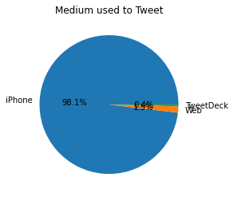

```python
plt.pie(source_tweet, labels= ['iPhone', 'Web', 'TweetDeck'], autopct ='%1.1f%%', pctdistance=0.5, labeldistance=1.1)
plt.title('Medium used to Tweet')
#plt.legend()
plt.show();
```

To investigate how the other variables in the dataset affect WeRate Dog Ratings, Favorite Count and Retweet Count

##### Questions to Investigate

1. Does the WeRate Dog Rating affect the number of favorites count and retweets?
2. Which Breed drew the highest rating, favorite counts and retweets?
3. Does the hour of the day affect the number retweets and favorites?
4. Do the retweet and favorite count increase by year?

##### Does the WeRate Dog Rating affect the number of favorites count and retweets?

```python
df.rating_numerator.value_counts()
```

```
12.0    216
11.0    209
10.0    208
13.0    131
9.0     77
8.0     48
7.0     23
14.0    17
5.0     14
6.0     12
Name: rating_numerator, dtype: int64
```

```python
fc_mean = df.groupby('rating_numerator')['favorite_count'].mean()
fc_mean
```

```
rating_numerator
5.0     3742.571429
6.0     2697.083333
7.0     3355.347826
8.0     2140.000000
9.0     2410.194805
10.0    3898.144231
11.0    6797.220096
12.0    10602.356481
13.0    23379.427481
14.0    27338.294118
Name: favorite_count, dtype: float64
```

```python
rc_mean = df.groupby('rating_numerator')['retweet_count'].mean()
rc_mean
```

```
rating_numerator
5.0     1540.571429
6.0     1097.916667
7.0     1232.304348
8.0     741.250000
9.0     782.519481
10.0    1396.086538
11.0    2080.382775
12.0    2963.138889
13.0    7446.175573
14.0    9337.352941
Name: retweet_count, dtype: float64
```

```python
wrd_ratings = [5.0, 6.0, 7.0, 8.0, 9.0, 10.0, 11.0, 12.0, 13.0, 14.0]
```

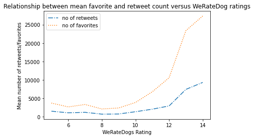

```python
#Plot mean result of mean favorite and retweet count agains WeRateDog ratings

plt.plot(wrd_ratings, rc_mean, label = "no of retweets", linestyle="-.")
plt.plot(wrd_ratings, fc_mean, label = "no of favorites", linestyle=":")
plt.legend()
plt.title("Relationship between mean favorite and retweet count versus WeRateDog ratings")
plt.xlabel("WeRateDogs Rating")
plt.ylabel('Mean number of retweets/favorites')
plt.show()
```

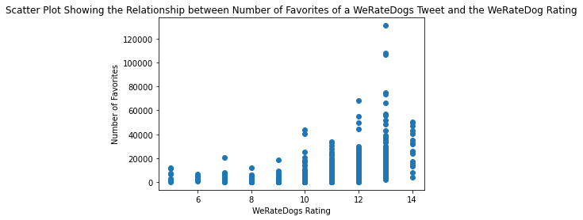

```python
plt.scatter(df.rating_numerator, df.favorite_count);
plt.title("Scatter Plot Showing the Relationship between Number of Favorites of a WeRateDogs Tweet and the WeRateDog Rating")
plt.xlabel("WeRateDogs Rating")
plt.ylabel("Number of Favorites");
```

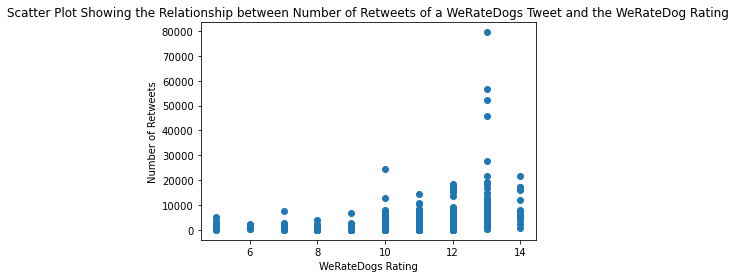

```python
plt.scatter(df.rating_numerator, df.retweet_count)
plt.title("Scatter Plot Showing the Relationship between Number of Retweets of a WeRateDogs Tweet and the WeRateDog Rating")
plt.xlabel("WeRateDogs Rating")
plt.ylabel("Number of Retweets");
```

##### Which Breed drew the highest rating, favorite counts and retweets?

We have already established that number of retweets and favorites correlates with high WeDog Rating

```python
df[df['rating_numerator']==14]
```

|  | tweet_id | timestamp | source | text | expanded_urls | rating_numerator | rating_denominator | stage | jpg_url | img_num | ... | p1_dog | p2 | p2_conf | p2_dog | p3 | p3_conf | p3_dog | retweet_count | favorite_count | retweeted |
| --- | --- | --- | --- | --- | --- | --- | --- | --- | --- | --- | --- | --- | --- | --- | --- | --- | --- | --- | --- | --- | --- |
| 4 | 890240255349198849 | 2017-07-26 15:59:51+00:00 | iPhone | This is Cassie. She is a college pup. Studying international doggo communication and stick theory. 14/10 so elegant much sophisticate https://t.co/t1bfwz5S2A | https://twitter.com/dog_rates/status/890240255349198849/photo/1 | 14.0 | 10 | doggo | https://pbs.twimg.com/media/DFrEyVuW0AAO3t9.jpg | 1.0 | ... | True | Cardigan | 0.451038 | True | Chihuahua | 0.029248 | True | 7711.0 | 32467.0 | False |
| 10 | 887517139158093824 | 2017-07-19 03:39:09+00:00 | iPhone | I've yet to rate a Venezuelan Hover Wiener. This is such an honor. 14/10 paw-inspiring af (IG: roxy.thedoxy) https://t.co/20VrLAA8ba | https://twitter.com/dog_rates/status/887517139158093824/video/1 | 14.0 | 10 | NaN | https://pbs.twimg.com/ext_tw_video_thumb/887517108413886465/pu/img/WanJKwssZj4VJvL9.jpg | 1.0 | ... | False | tow_truck | 0.029175 | False | shopping_cart | 0.026321 | False | 12082.0 | 46959.0 | False |
| 23 | 881536004380872706 | 2017-07-02 15:32:16+00:00 | iPhone | Here is a pupper approaching maximum borkdrive. Zooming at never before seen speeds. 14/10 paw-inspiring af \n(IG: puffie_the_chow) https://t.co/ghXBIIeQZF | https://twitter.com/dog_rates/status/881536004380872706/video/1 | 14.0 | 10 | pupper | https://pbs.twimg.com/ext_tw_video_thumb/881535971568889856/pu/img/9bawiZ--8FKywTkz.jpg | 1.0 | ... | True | Angora | 0.272066 | False | Persian_cat | 0.114854 | False | 16570.0 | 50199.0 | False |
| 29 | 878057613040115712 | 2017-06-23 01:10:23+00:00 | iPhone | This is Emmy. She was adopted today. Massive round of pupplause for Emmy and her new family. 14/10 for all involved https://t.co/cwtWnHMVpe | https://twitter.com/dog_rates/status/878057613040115712/photo/1,https://twitter.com/dog_rates/status/878057613040115712/photo/1 | 14.0 | 10 | NaN | https://pbs.twimg.com/media/DC98vABUIAA97pz.jpg | 1.0 | ... | True | Boston_bull | 0.078799 | True | toy_terrier | 0.015243 | True | 7181.0 | 42876.0 | False |
| 63 | 860184849394610176 | 2017-05-04 17:30:24+00:00 | iPhone | Here we have perhaps the wisest dog of all. Above average with light sabers. Immortal as h*ck. 14/10 dog, or dog not, there is no try https://t.co/upRYxG4KbG | https://twitter.com/dog_rates/status/860184849394610176/photo/1 | 14.0 | 10 | NaN | https://pbs.twimg.com/media/C-_9jWWUwAAnwkd.jpg | 1.0 | ... | False | gorilla | 0.104293 | False | orangutan | 0.059908 | False | 6295.0 | 17474.0 | False |
| 78 | 851464819735769094 | 2017-04-10 16:00:07+00:00 | iPhone | This is Iggy. He was a rescue dog killed in the Stockholm attack. His memorial started with a collar and four bones. It's grown a bit. 14/10 https://t.co/E4a0R9my1M | https://twitter.com/dog_rates/status/851464819735769094/photo/1,https://twitter.com/dog_rates/status/851464819735769094/photo/1,https://twitter.com/dog_rates/status/851464819735769094/photo/1,https://… | 14.0 | 10 | NaN | https://pbs.twimg.com/media/C9ECujZXsAAPCSM.jpg | 2.0 | ... | False | menu | 0.026306 | False | crossword_puzzle | 0.003482 | False | 7855.0 | 25944.0 | False |
| 96 | 841439858740625411 | 2017-03-14 00:04:30+00:00 | iPhone | Here we have some incredible doggos for #K9VeteransDay. All brave as h*ck. Salute your dog in solidarity. 14/10 for all https://t.co/SVNMdFqKDL | https://twitter.com/dog_rates/status/841439858740625411/photo/1,https://twitter.com/dog_rates/status/841439858740625411/photo/1,https://twitter.com/dog_rates/status/841439858740625411/photo/1,https://… | 14.0 | 10 | NaN | https://pbs.twimg.com/media/C61lFFiWoAAJdiL.jpg | 3.0 | ... | False | Labrador_retriever | 0.048200 | True | groenendael | 0.015394 | True | 4168.0 | 13755.0 | False |
| 135 | 828381636999917570 | 2017-02-05 23:15:47+00:00 | iPhone | Meet Doobert. He's a deaf doggo. Didn't stop him on the field tho. Absolute legend today. 14/10 would pat head approvingly https://t.co/iCk7zstRA9 | https://twitter.com/dog_rates/status/828381636999917570/photo/1 | 14.0 | 10 | doggo | https://pbs.twimg.com/media/C38Asz1WEAAvzj3.jpg | 1.0 | ... | True | Labrador_retriever | 0.089022 | True | clumber | 0.081800 | True | 2554.0 | 13864.0 | False |
| 154 | 822462944365645825 | 2017-01-20 15:17:01+00:00 | iPhone | This is Gabe. He was the unequivocal embodiment of a dream meme, but also one h*ck of a pupper. You will be missed by so many. 14/10 RIP https://t.co/M3hZGadUuO | https://twitter.com/dog_rates/status/822462944365645825/photo/1,https://twitter.com/dog_rates/status/822462944365645825/photo/1,https://twitter.com/dog_rates/status/822462944365645825/photo/1,https://… | 14.0 | 10 | pupper | https://pbs.twimg.com/media/C2n5rUUXEAIXAtv.jpg | 3.0 | ... | True | Samoyed | 0.023056 | True | Maltese_dog | 0.008945 | True | 17209.0 | 31800.0 | False |
| 156 | 821407182352777218 | 2017-01-17 17:21:47+00:00 | iPhone | This is Sundance. He's a doggo drummer. Even sings a bit on the side. 14/10 entertained af (vid by @sweetsundance) https://t.co/Xn5AQtiqzG | https://twitter.com/dog_rates/status/821407182352777218/video/1 | 14.0 | 10 | doggo | https://pbs.twimg.com/ext_tw_video_thumb/821407155391725568/pu/img/AJC07gFJDDBuwNTD.jpg | 1.0 | ... | True | vizsla | 0.168747 | True | Chesapeake_Bay_retriever | 0.111311 | True | 5053.0 | 13075.0 | False |
| 160 | 820314633777061888 | 2017-01-14 17:00:24+00:00 | iPhone | We are proud to support @LoveYourMelon on their mission to put a hat on every kid battling cancer. They are 14/10\n\nhttps://t.co/XQlmPTLHPl https://t.co/ZNIkkHgtYE | https://www.loveyourmelon.com/pages/ourstory,https://twitter.com/dog_rates/status/820314633777061888/photo/1,https://twitter.com/dog_rates/status/820314633777061888/photo/1,https://twitter.com/dog_rat… | 14.0 | 10 | NaN | https://pbs.twimg.com/media/C2JXyARUAAE4gbL.jpg | 2.0 | ... | True | black-and-tan_coonhound | 0.042041 | True | Rottweiler | 0.009417 | True | 648.0 | 3706.0 | False |
| 163 | 819006400881917954 | 2017-01-11 02:21:57+00:00 | iPhone | This is Sunny. She was also a very good First Doggo. 14/10 would also be an absolute honor to pet https://t.co/YOC1fHFCSb | https://twitter.com/dog_rates/status/819006400881917954/photo/1,https://twitter.com/dog_rates/status/819006400881917954/photo/1,https://twitter.com/dog_rates/status/819006400881917954/photo/1,https://… | 14.0 | 10 | doggo | https://pbs.twimg.com/media/C12x-JTVIAAzdfl.jpg | 4.0 | ... | False | palace | 0.020089 | False | umbrella | 0.007850 | False | 21794.0 | 49960.0 | False |
| 179 | 813812741911748608 | 2016-12-27 18:24:12+00:00 | iPhone | Meet Gary, Carrie Fisher's dog. Idk what I can say about Gary that reflects the inspirational awesomeness that was Carrie Fisher. 14/10 RIP https://t.co/uBnQTNEeGg | https://twitter.com/dog_rates/status/813812741911748608/photo/1,https://twitter.com/dog_rates/status/813812741911748608/photo/1,https://twitter.com/dog_rates/status/813812741911748608/photo/1 | 14.0 | 10 | NaN | https://pbs.twimg.com/media/C0s-XtzWgAAp1W-.jpg | 1.0 | ... | True | Boston_bull | 0.247621 | True | boxer | 0.018855 | True | 16267.0 | 40402.0 | False |
| 270 | 778408200802557953 | 2016-09-21 01:39:11+00:00 | iPhone | RIP Loki. Thank you for the good times. You will be missed by many. 14/10 https://t.co/gJKD9pst5A | https://twitter.com/dog_rates/status/778408200802557953/photo/1,https://twitter.com/dog_rates/status/778408200802557953/photo/1,https://twitter.com/dog_rates/status/778408200802557953/photo/1,https://… | 14.0 | 10 | NaN | https://pbs.twimg.com/media/Cs12ICuWAAECNRy.jpg | 3.0 | ... | True | Cardigan | 0.108124 | True | beagle | 0.011942 | True | 5023.0 | 15135.0 | False |
| 281 | 774314403806253056 | 2016-09-09 18:31:54+00:00 | iPhone | I WAS SENT THE ACTUAL DOG IN THE PROFILE PIC BY HIS OWNER THIS IS SO WILD. 14/10 ULTIMATE LEGEND STATUS https://t.co/7oQ1wpfxIH | https://twitter.com/dog_rates/status/774314403806253056/photo/1,https://twitter.com/dog_rates/status/774314403806253056/photo/1,https://twitter.com/dog_rates/status/774314403806253056/photo/1,https://… | 14.0 | 10 | NaN | https://pbs.twimg.com/media/Cr7q1VxWIAA5Nm7.jpg | 3.0 | ... | True | Siberian_husky | 0.223067 | True | Saluki | 0.036325 | True | 6478.0 | 24167.0 | False |
| 382 | 742465774154047488 | 2016-06-13 21:16:49+00:00 | iPhone | Was just informed about this hero pupper and others like her. Another 14/10, would be an absolute honor to pet https://t.co/hBTzPmj36Z | https://twitter.com/dog_rates/status/742465774154047488/photo/1,https://twitter.com/dog_rates/status/742465774154047488/photo/1 | 14.0 | 10 | pupper | https://pbs.twimg.com/media/Ck3EribXEAAPhZn.jpg | 1.0 | ... | False | comic_book | 0.000439 | False | desktop_computer | 0.000268 | False | 4382.0 | 7916.0 | False |
| 616 | 685547936038666240 | 2016-01-08 19:45:39+00:00 | iPhone | Everybody needs to read this. Jack is our first 14/10. Truly heroic pupper https://t.co/3m6bNGXWnM | https://twitter.com/dog_rates/status/685547936038666240/photo/1,https://twitter.com/dog_rates/status/685547936038666240/photo/1 | 14.0 | 10 | pupper | https://pbs.twimg.com/media/CYOONfZW8AA7IOA.jpg | 1.0 | ... | False | oscilloscope | 0.009712 | False | hand-held_computer | 0.008769 | False | 17465.0 | 35052.0 | False |

17 rows × 22 columns

```python
df_breeds = df.query('p1_dog == True') #only considering tweets wthat have been indentified as dog breeds
top_10 = df_breeds.p1.value_counts()[0:10] #Top 10 dog breeds rated
top_10
```

```
golden_retriever      68
Labrador_retriever    48
Pembroke              43
Chihuahua             42
pug                   23
Pomeranian            21
Samoyed               21
chow                  20
toy_poodle            19
French_bulldog        17
Name: p1, dtype: int64
```

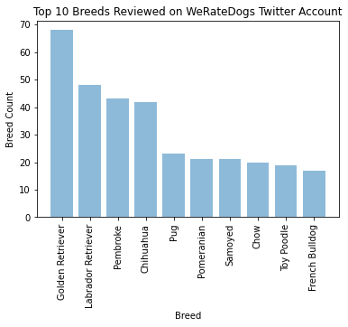

```python
labels = [ 'Golden Retriever', 'Labrador Retriever', 'Pembroke', 'Chihuahua', 'Pug', 'Pomeranian', 'Samoyed', 'Chow',
          'Toy Poodle', 'French Bulldog']

plt.bar(labels, top_10, align='center', alpha=0.5)
plt.ylabel('Breed Count')
plt.xlabel('Breed')
plt.title('Top 10 Breeds Reviewed on WeRateDogs Twitter Account')
plt.xticks(rotation=90)
plt.show()
```

```python
df_breeds.p1.count() #number of dog breeds rated
```

```
724
```

```python
(68+48+43)/724
```

```
0.21961325966850828
```

Will consider 11-13 Ratings

```python
df_13 = df.query('rating_numerator == 13 & p1_dog == True') #only considering tweets where numerator rating is 13 and are dog breeds
```

```python
df_13.p1.unique()
```

```
array(['Chihuahua', 'Chesapeake_Bay_retriever', 'Pomeranian',
       'French_bulldog', 'whippet', 'golden_retriever',
       'Mexican_hairless', 'pug', 'chow', 'Eskimo_dog', 'Pembroke',
       'Saluki', 'English_springer', 'vizsla', 'Labrador_retriever',
       'cocker_spaniel', 'Cardigan', 'Newfoundland', 'Shetland_sheepdog',
       'Greater_Swiss_Mountain_dog', 'Border_collie',
       'Bedlington_terrier', 'Samoyed', 'German_shepherd',
       'giant_schnauzer', 'Dandie_Dinmont', 'Afghan_hound', 'Leonberg',
       'Border_terrier', 'Great_Pyrenees',
       'American_Staffordshire_terrier', 'West_Highland_white_terrier',
       'briard', 'toy_poodle', 'Pekinese', 'Doberman',
       'curly-coated_retriever', 'Tibetan_mastiff', 'Rottweiler',
       'collie', 'borzoi', 'Great_Dane', 'malinois', 'Norfolk_terrier',
       'Lakeland_terrier', 'Gordon_setter'], dtype=object)
```

```python
df_13.p1.value_counts()[0:3] #Top 3 popular dog breeds rated 13
```

```
golden_retriever      17
Pembroke              9
Labrador_retriever    8
Name: p1, dtype: int64
```

```python
df_13.groupby('p1')['retweet_count'].mean().sort_values(ascending = False)[0:3] #Top 3 most retweeted dog breeds rated 13
```

```
p1
English_springer      45849.00
Eskimo_dog            28241.00
Labrador_retriever    17454.25
Name: retweet_count, dtype: float64
```

```python
df_13.groupby('p1')['favorite_count'].mean().sort_values(ascending = False)[0:3] #Top 3 most favorited dog breeds rated 13
```

```
p1
English_springer    107956.0
Pomeranian          56848.0
Eskimo_dog          49804.0
Name: favorite_count, dtype: float64
```

```python
df_12 = df.query('rating_numerator == 12 & p1_dog == True') #only considering tweets where numerator rating is 12 and are dog breeds
```

```python
df_12.p1.unique()
```

```
array(['French_bulldog', 'Italian_greyhound', 'Doberman',
       'golden_retriever', 'bloodhound', 'Labrador_retriever', 'vizsla',
       'komondor', 'whippet', 'flat-coated_retriever', 'Samoyed',
       'bull_mastiff', 'German_shepherd', 'Pembroke', 'Shetland_sheepdog',
       'Airedale', 'chow', 'Chesapeake_Bay_retriever', 'Border_collie',
       'Rhodesian_ridgeback', 'Cardigan', 'Eskimo_dog', 'cocker_spaniel',
       'Border_terrier', 'malamute', 'Great_Pyrenees', 'malinois',
       'Old_English_sheepdog', 'Chihuahua', 'miniature_schnauzer',
       'Pomeranian', 'miniature_poodle', 'Staffordshire_bullterrier',
       'Norwegian_elkhound', 'Tibetan_mastiff', 'miniature_pinscher',
       'Siberian_husky', 'American_Staffordshire_terrier', 'collie',
       'Leonberg', 'Lakeland_terrier', 'toy_poodle', 'beagle',
       'Bernese_mountain_dog', 'Pekinese', 'kuvasz', 'boxer',
       'Yorkshire_terrier', 'Brittany_spaniel', 'briard', 'papillon',
       'Shih-Tzu', 'Great_Dane', 'Lhasa', 'bluetick', 'kelpie',
       'standard_schnauzer', 'Scottish_deerhound', 'Rottweiler',
       'redbone', 'Maltese_dog'], dtype=object)
```

```python
df_12.p1.value_counts()[0:3] #Top 3 popular dog breeds rated 12
```

```
golden_retriever      30
Pembroke              13
Labrador_retriever    10
Name: p1, dtype: int64
```

```python
df_12.groupby('p1')['retweet_count'].mean().sort_values(ascending = False)[0:3] #Top 3 most retweeted dog breeds rated 12
```

```
p1
Italian_greyhound    8745.5
collie               7726.0
Samoyed              6905.0
Name: retweet_count, dtype: float64
```

```python
df_12.groupby('p1')['favorite_count'].mean().sort_values(ascending = False)[0:3] #Top 3 most favorited dog breeds rated 12
```

```
p1
Italian_greyhound    35826.50
Border_collie        28552.00
French_bulldog       24115.75
Name: favorite_count, dtype: float64
```

```python
df_11 = df.query('rating_numerator == 11 & p1_dog == True') #only considering tweets where numerator rating is 11 and are dog breeds
```

```python
df_11.p1.unique()
```

```
array(['miniature_pinscher', 'basset', 'English_springer', 'pug',
       'Labrador_retriever', 'Staffordshire_bullterrier', 'kelpie',
       'French_bulldog', 'Doberman', 'Border_collie', 'malamute',
       'vizsla', 'chow', 'American_Staffordshire_terrier',
       'Lakeland_terrier', 'Italian_greyhound', 'Chihuahua',
       'Chesapeake_Bay_retriever', 'golden_retriever', 'Mexican_hairless',
       'Siberian_husky', 'cocker_spaniel', 'beagle', 'Pembroke',
       'papillon', 'collie', 'Welsh_springer_spaniel', 'Gordon_setter',
       'Blenheim_spaniel', 'toy_poodle', 'Shetland_sheepdog', 'Samoyed',
       'bull_mastiff', 'Cardigan', 'Pomeranian', 'Eskimo_dog',
       'Maltese_dog', 'Newfoundland', 'Dandie_Dinmont',
       'Brittany_spaniel', 'Old_English_sheepdog', 'basenji',
       'Boston_bull', 'Great_Pyrenees', 'boxer', 'borzoi',
       'Norwich_terrier', 'Yorkshire_terrier', 'Bernese_mountain_dog',
       'Airedale', 'schipperke', 'Irish_setter', 'EntleBucher',
       'Shih-Tzu', 'Pekinese', 'Sussex_spaniel', 'Irish_terrier',
       'kuvasz', 'soft-coated_wheaten_terrier', 'English_setter'],
      dtype=object)
```

```python
df_11.p1.value_counts()[0:3] #Top 3 popular dog breeds rated 11
```

```
Labrador_retriever    13
golden_retriever      11
Pembroke              10
Name: p1, dtype: int64
```

```python
df_11.groupby('p1')['retweet_count'].mean().sort_values(ascending = False)[0:3] #Top 3 most retweeted dog breeds rated 11
```

```
p1
Great_Pyrenees    10673.0
collie            5912.0
Cardigan          4399.5
Name: retweet_count, dtype: float64
```

```python
df_11.groupby('p1')['favorite_count'].mean().sort_values(ascending = False)[0:3] #Top 3 most favorited dog breeds rated 11
```

```
p1
Great_Pyrenees        25130.000000
English_springer      17169.000000
miniature_pinscher    13975.333333
Name: favorite_count, dtype: float64
```

##### Does the hour of the day affect the number retweets and favorites?

```python
df.timestamp = pd.to_datetime(df.timestamp) #observed that timestamp has reverted to string
```

```python
type(df.timestamp[0])
```

```
pandas._libs.tslibs.timestamps.Timestamp
```

```python
df['hour'] = df['timestamp'].dt.hour #adding a new column to depict the hour of posting
```

```python
postcountbyhour = df.groupby('hour').tweet_id.count()
postcountbyhour
```

```
hour
0     116
1     133
2     103
3     79
4     48
5     13
6     2
13    1
14    5
15    50
16    92
17    76
18    44
19    41
20    34
21    33
22    29
23    56
Name: tweet_id, dtype: int64
```

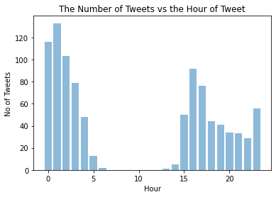

```python
#The Number of Tweets vs the Hour of Tweet
labels = [0, 1, 2, 3, 4, 5, 6, 13, 14, 15, 16, 17, 18, 19, 20, 21, 22, 23]

plt.bar(labels, postcountbyhour, align='center', alpha=0.5)
plt.ylabel('No of Tweets')
plt.xlabel('Hour')
plt.title('The Number of Tweets vs the Hour of Tweet')

plt.show()
```

```python
rc_hour = df.groupby('hour').retweet_count.mean()
rc_hour
```

```
hour
0     3894.965517
1     2658.616541
2     1565.854369
3     1520.164557
4     997.916667
5     1917.153846
6     28480.500000
13    409.000000
14    1801.800000
15    3551.560000
16    3721.521739
17    2383.973684
18    4894.863636
19    3722.073171
20    2143.617647
21    1945.151515
22    1981.655172
23    3012.107143
Name: retweet_count, dtype: float64
```

```python
fc_hour = df.groupby('hour').favorite_count.mean()
fc_hour
```

```
hour
0     13364.922414
1     9298.165414
2     4238.213592
3     4235.582278
4     2821.541667
5     4246.307692
6     53856.500000
13    749.000000
14    5895.600000
15    11263.400000
16    14175.934783
17    8625.947368
18    11400.863636
19    10317.804878
20    6647.470588
21    5810.242424
22    7621.344828
23    9395.714286
Name: favorite_count, dtype: float64
```

[figure not shown]

```python
#https://matplotlib.org/stable/gallery/lines_bars_and_markers/barchart.html
labels = [0, 1, 2, 3, 4, 5, 6, 13, 14, 15, 16, 17, 18, 19, 20, 21, 22, 23]

x = np.arange(len(labels))  # the label locations
width = 0.35  # the width of the bars

fig, ax = plt.subplots()
rects1 = ax.bar(x - width/2, rc_hour, width, label='No of Retweets')
rects2 = ax.bar(x + width/2, fc_hour, width, label='No of Favorites')

plt.ylabel('Mean number of retweets/favorites')
plt.xlabel('WeRateDog Rating')
plt.title('Average number of Retweets/Favorites vs Hour of Posting')
ax.legend()

fig.tight_layout()

plt.show()
```

```python
df.query('hour == 6')
```

|  | tweet_id | timestamp | source | text | expanded_urls | rating_numerator | rating_denominator | stage | jpg_url | img_num | ... | p2 | p2_conf | p2_dog | p3 | p3_conf | p3_dog | retweet_count | favorite_count | retweeted | hour |
| --- | --- | --- | --- | --- | --- | --- | --- | --- | --- | --- | --- | --- | --- | --- | --- | --- | --- | --- | --- | --- | --- |
| 196 | 807106840509214720 | 2016-12-09 06:17:20+00:00 | iPhone | This is Stephan. He just wants to help. 13/10 such a good boy https://t.co/DkBYaCAg2d | https://twitter.com/dog_rates/status/807106840509214720/video/1 | 13.0 | 10 | NaN | https://pbs.twimg.com/ext_tw_video_thumb/807106774843039744/pu/img/8XZg1xW35Xp2J6JW.jpg | 1.0 | ... | Pomeranian | 0.120358 | True | toy_terrier | 0.077008 | True | 56625.0 | 107015.0 | False | 6 |
| 874 | 669037058363662336 | 2015-11-24 06:17:19+00:00 | iPhone | Here we have Pancho and Peaches. Pancho is a Condoleezza Gryffindor, and Peaches is just an asshole. 10/10 &amp; 7/10 https://t.co/Lh1BsJrWPp | https://twitter.com/dog_rates/status/669037058363662336/photo/1 | 10.0 | 10 | NaN | https://pbs.twimg.com/media/CUjlp51WcAA1vGA.jpg | 1.0 | ... | Pomeranian | 0.053871 | True | chow | 0.032257 | True | 336.0 | 698.0 | False | 6 |

2 rows × 23 columns

##### Do the retweet and favorite count increase by year?

```python
df['year'] = df['timestamp'].dt.year #adding a new column to depict the year of posting
```

```python
df.groupby('year').tweet_id.count()
```

```
year
2015    314
2016    464
2017    177
Name: tweet_id, dtype: int64
```

```python
df.groupby('year').retweet_count.mean()
```

```
year
2015    832.038217
2016    2999.060345
2017    5680.813559
Name: retweet_count, dtype: float64
```

### Insights:

1. Based on the cleaned data, 98% of the tweets from the WeRateDogs account were from an iPhone
2. 12/10 was the most popular rating used on the account Whereas 6/10, was the least popular rating on the account
3. There is a positive correlation between Retweet/Favorite Count and WeRateDog Rating for WeRateDog Rating greater than 9/10, while there is no correlation for ratings less than 9/10
4. Golden retrievers, Labrador retrievers, and Pembroke breeds are the most reviewed dog breed by WeRateDog Twitter account. In terms of the WeRateDogs Rating, the highest retweeted/favorited dog breeds are:

   ```
    a. 13/10 : English Springer
    b. 12/10 : Italian Greyhound
    c. 11/10  : Great Pyrenees
   ```

### Visualization

Visualizations are embedded in the analysis section